# shiny-results slides

```python
# automatically show plots inside the notebook
%matplotlib inline

# reload all modules before executing code
%load_ext autoreload
%autoreload 2
```

```python
# you will use this notebook as a basis to walk us through what you did
```

```python
# import independent features
import pandas as pd
import numpy as np
features = pd.read_csv('../data/features.csv')
features.shape
```

```
(288, 688)
```

There are 688 independent features for 288 patients. However, it is quiet possible that many of these features are redundant. Therefore, I employ exploratory data analysis namely univariate and bivariate analysis to eliminate redundant features.

```python
# bivariate analysis
corr_matrix = features.corr().abs()
upper = corr_matrix.where(np.triu(np.ones(corr_matrix.shape), k=1).astype(np.bool))
to_drop = [column for column in upper.columns if any(upper[column] > 0.90)]
features = features.drop(features[to_drop], axis=1)
features.shape
```

```
(288, 237)
```

As one can see, more than half of features had a correlation of more than 90% with other features. One can adjust correlation threshold on a need basis.

```python
# univariate analysis
X = features.iloc[:, 1:].values
from sklearn.feature_selection import VarianceThreshold
vt = VarianceThreshold(0.2)
X = vt.fit_transform(X)
X.shape
```

```
(288, 171)
```

With univariate analysis, I try to remove those features which have variance below 0.2 . Reason being, features with lesser variance will not be able to distinguish the data effectively.

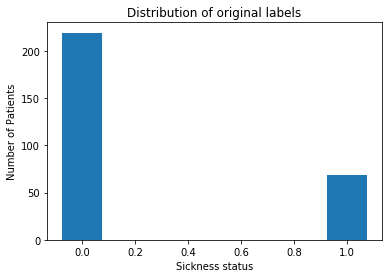

```python
# import labels - 1-sick or 0-healthy
from matplotlib import pyplot as plt
labels = pd.read_csv('../data/labels.csv')
y = labels.iloc[:, 1].values
x_1 = [0,1]
x_2 = [y.size - np.count_nonzero(y), np.count_nonzero(y)]
plt.figure(1)
plt.bar(x_1, x_2,width=0.15, align = 'center')
plt.title('Distribution of original labels')
plt.ylabel('Number of Patients')
plt.xlabel('Sickness status')
plt.show()
```

Distribution of labels is skewed towards helathy patients. Number of healthy patients is more than double the size of sick patients.

```python
# feature Scaling
from sklearn.preprocessing import StandardScaler
sc = StandardScaler()
X = sc.fit_transform(X)
```

Feature scaling is an important preprocessing step since we do not wish to see one feature influencing the result more than the others. Feature scaling essentially standardizes features by removing the mean and scaling to unit variance

```python
from sklearn.decomposition import PCA
pca = PCA(n_components = 50)
X = pca.fit_transform(X)
explained_variance = pca.explained_variance_ratio_
print(sum(explained_variance))
```

```
0.9088261438680943
```

PCA is a feature extraction technique. It is a unsupervised, generates topN eigen vectors with a highest variance. I selected top 50 features that account for 90% of the variance. Instead of using 688 features with 100% variance, I rather choose small subset of features to account for lesser variance.

```python
# create ANN model
import keras
from keras.models import Sequential
from keras.layers import Dense, Dropout

classifier = Sequential()
classifier.add(Dropout(0.3, input_shape = (50,)))
classifier.add(Dense(21,  activation='relu', kernel_initializer = 'uniform'))
classifier.add(Dropout(0.5))
classifier.add(Dense(21, activation='relu', kernel_initializer='uniform'))
classifier.add(Dropout(0.5))
classifier.add(Dense(1, activation='sigmoid', kernel_initializer='uniform'))
```

ANN has been used for binary classification task in here. It is a sequential model with 2 hidden layers and 3 regularization layers. DropOut layer reduces overfitting in this case.

```python
# compile, fit and predict
classifier.compile(optimizer='adam', loss='binary_crossentropy', metrics=['accuracy'])
classifier.fit(X, y, batch_size=10, epochs=500)
y_pred = classifier.predict(X)
y_pred = (y_pred > 0.4)
```

I use 500 epochs with batch size of 10 to train ANN model. Since we are more concerned about identifying sick people rather than misclassifying a healthy person, I slighly reduce the threshold to 0.4 .

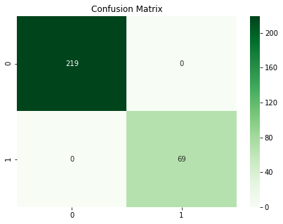

```python
from sklearn.metrics import confusion_matrix, recall_score
import seaborn as sn
cm = confusion_matrix(y, y_pred)
plt.figure(figsize = (7,5))
plt.title('Confusion Matrix')
sn.heatmap(cm, annot=True, cmap='Greens', fmt='g')
```

```python
# recall -
recall = recall_score(y, y_pred)
print(recall)
```

```
1.0
```

We are more concerned about false negatives (categorizing sick person as healthy) than false positives (categorizing healthy person as sick), recall is a good indicator of how well we perform in this scenario. Recall score was 1.0 when I ran for the last time. Essentially, there were no false negatives. Since we have taken care of overfitting through regularization, we assume prediction is stable across datasets i.e low variance. A test set could have helped me in this regard.

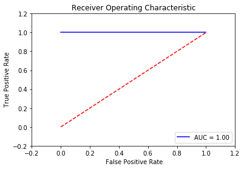

```python
# roc curve
from sklearn.metrics import roc_curve, auc
false_positive_rate, true_positive_rate, thresholds = roc_curve(y, y_pred)
roc_auc = auc(false_positive_rate, true_positive_rate)
plt.figure(2)
plt.title('Receiver Operating Characteristic')
plt.plot(false_positive_rate, true_positive_rate, 'b',
label='AUC = %0.2f'% roc_auc)
plt.legend(loc='lower right')
plt.plot([0,1],[0,1],'r--')
plt.xlim([-0.2,1.2])
plt.ylim([-0.2,1.2])
plt.ylabel(' True Positive Rate')
plt.xlabel(' False Positive Rate')
plt.show()
```

Receiver operating characteristic (ROC) is used to visualize the performance of a binary classifier. It helps to select model independent of the class distribution (Fig.1). We can see that our model has the best possible performance in ROC curve. Dotted line denotes random classifier.

Finally, We have to take this result with a pinch of salt. There is a high possibility of overfitting since dataset is really small. We could enhance the perrformance of this classifier by increasing dataset, providing a test/validation set or by cross validation etc.